# Session 3 Practice: Data visualization with `ggplot2`

Kenneth Tay

Oct 1, 2019

**Note: There are often multiple ways to answer each question.**

Load the `ggplot2` and `fueleconomy` packages, as well as the `vehicles` dataset.

```r
library(ggplot2)
library(fueleconomy)
data(vehicles)
```

1. Make a scatterplot of `hwy` vs. `cty`.

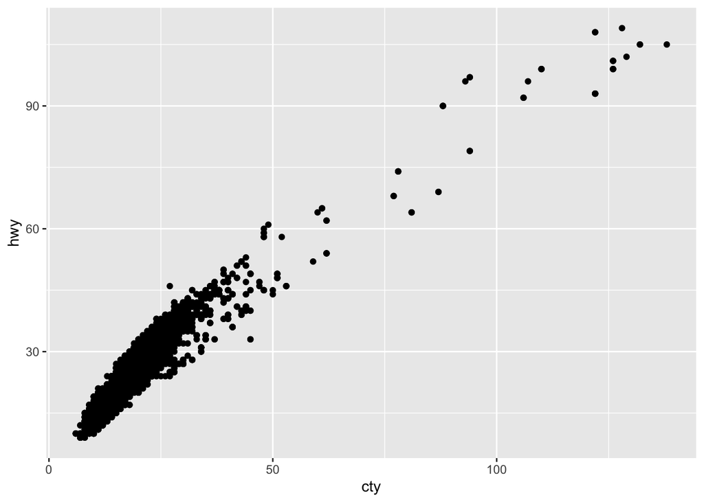

```r
ggplot(vehicles, aes(x = cty, y = hwy)) +
    geom_point()
```

2. Convert the `cyl` column to a factor.

```r
vehicles$cyl <- factor(vehicles$cyl)
```

3. Modify the plot from Qn 1 such that the color of the dot represents `cyl` value. Also, change the color scale to “YlOrRd”.

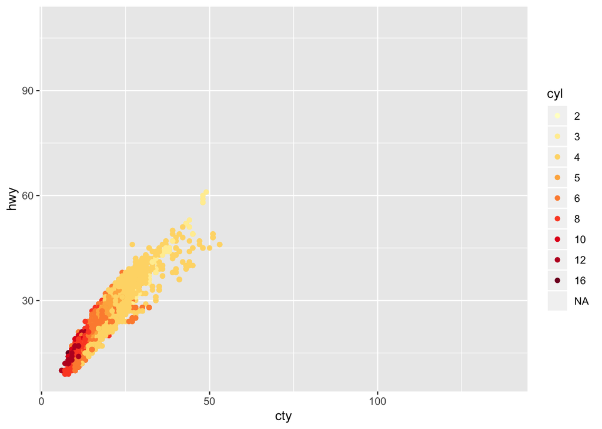

```r
ggplot(vehicles, aes(x = cty, y = hwy, col = cyl)) +
    geom_point() +
    scale_color_brewer(palette = "YlOrRd")
```

Notice how the NAs got removed!

4. There is a lot of overplotting in the plot above. Remove the color scale and modify the previous plot so that `alpha = 0.1`.

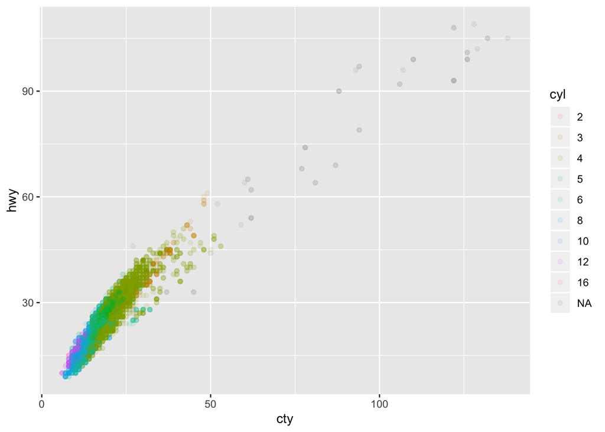

```r
ggplot(vehicles, aes(x = cty, y = hwy, col = cyl)) +
    geom_point(alpha = 0.1)
```

5. Make a histogram of `year`.

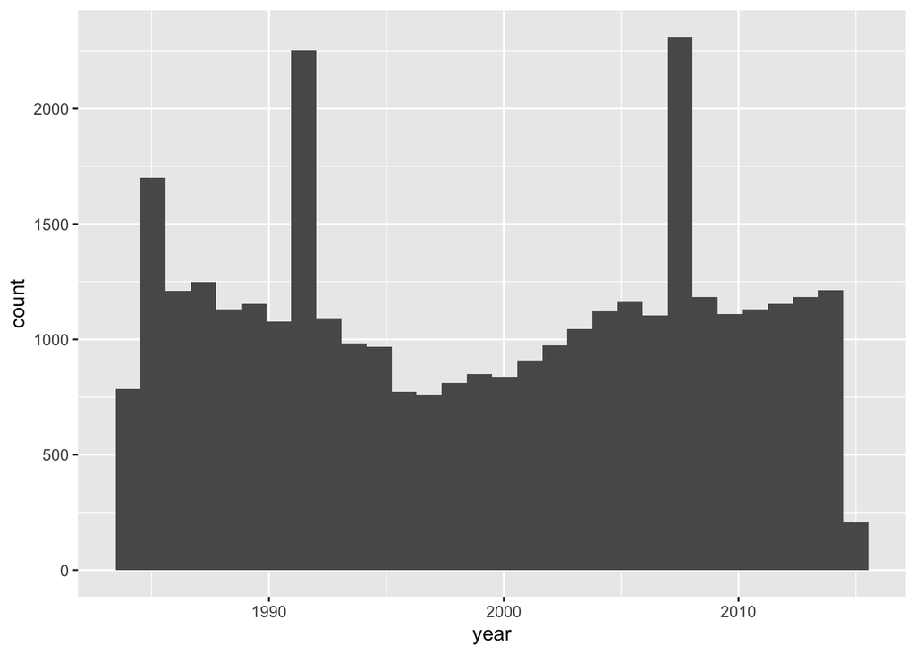

```r
ggplot(vehicles, aes(x = year)) +
    geom_histogram()
```

6. Make a histogram of `year` with just 5 bins.

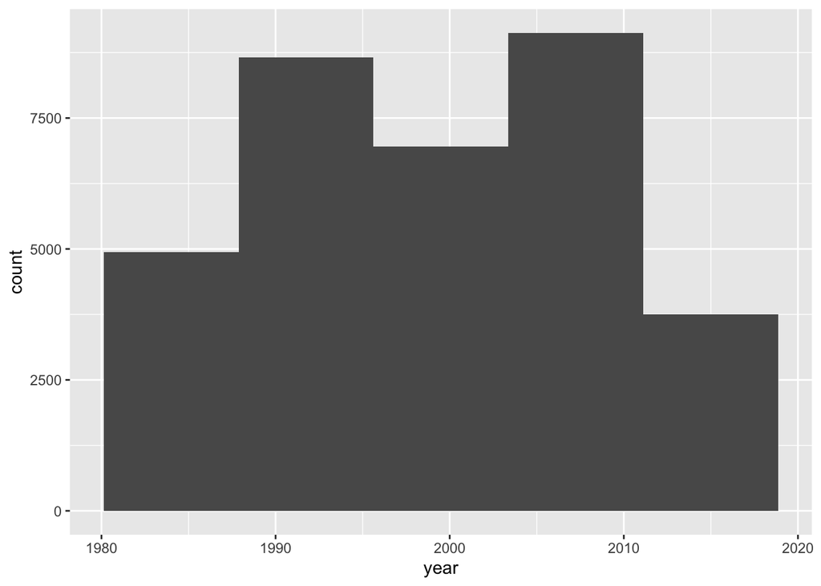

```r
ggplot(vehicles, aes(x = year)) +
    geom_histogram(bins = 5)
```

7. For each value of `cyl`, make a violin plot of `hwy` values.

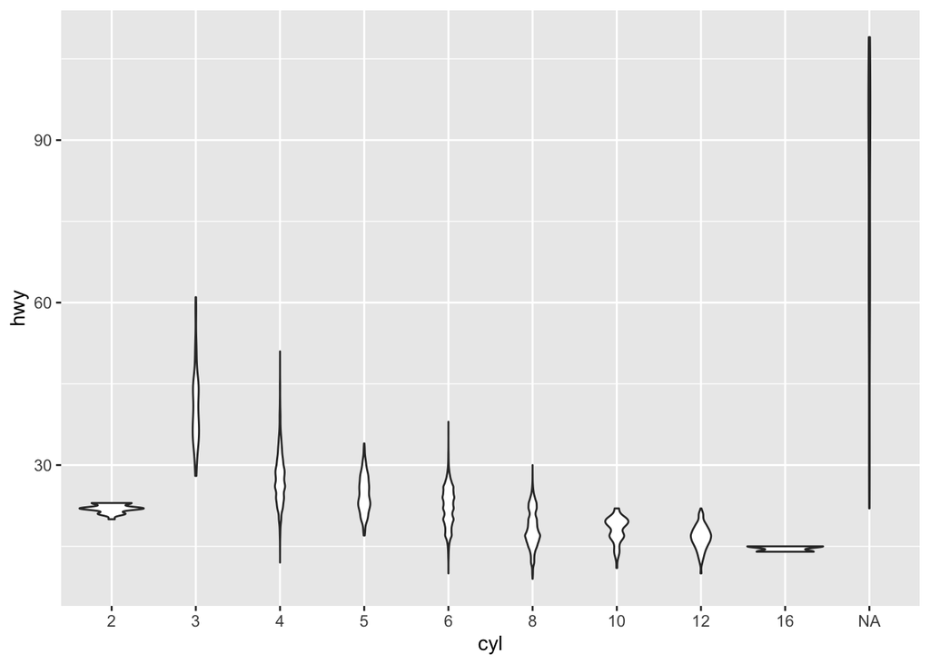

```r
ggplot(vehicles, aes(x = cyl, y = hwy)) +
    geom_violin()
```

8. For each value of `cyl`, make a boxplot of `hwy` values.

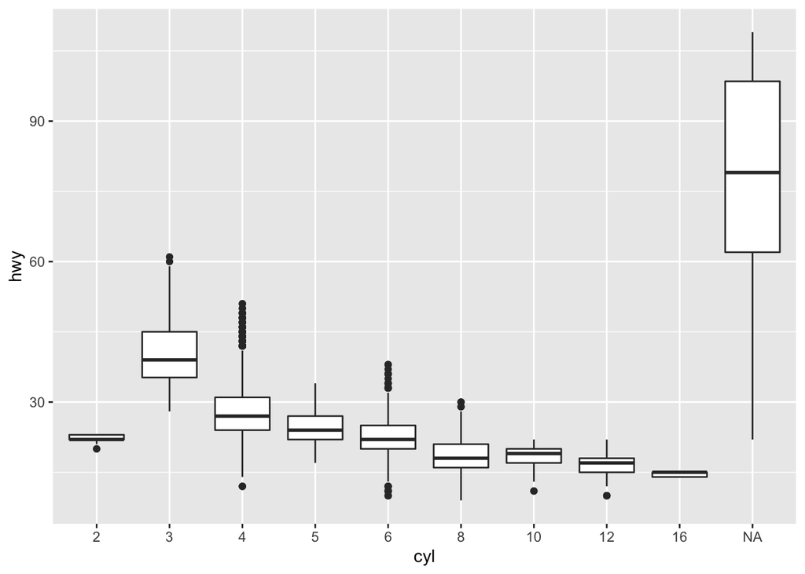

```r
ggplot(vehicles, aes(x = cyl, y = hwy)) +
    geom_boxplot()
```

9. Make a barplot to show how many cars of each type of `fuel` there are in the dataset. (Hint: Use the `geom_bar` geom.)

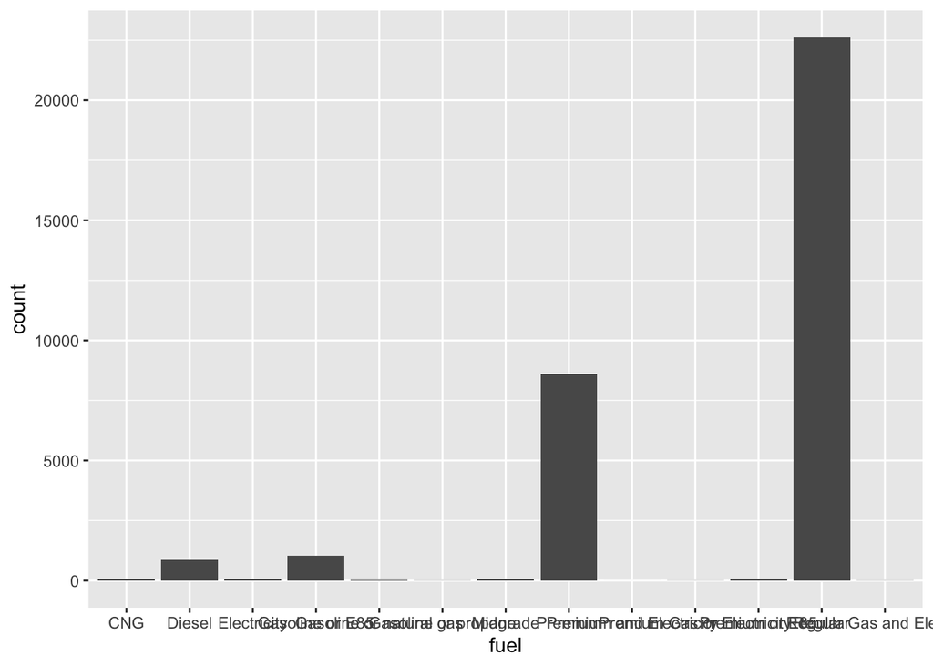

```r
ggplot(vehicles, aes(x = fuel)) +
    geom_bar()
```

10. Add a `coord_flip()` layer to the previous plot to make a horizontal barplot.

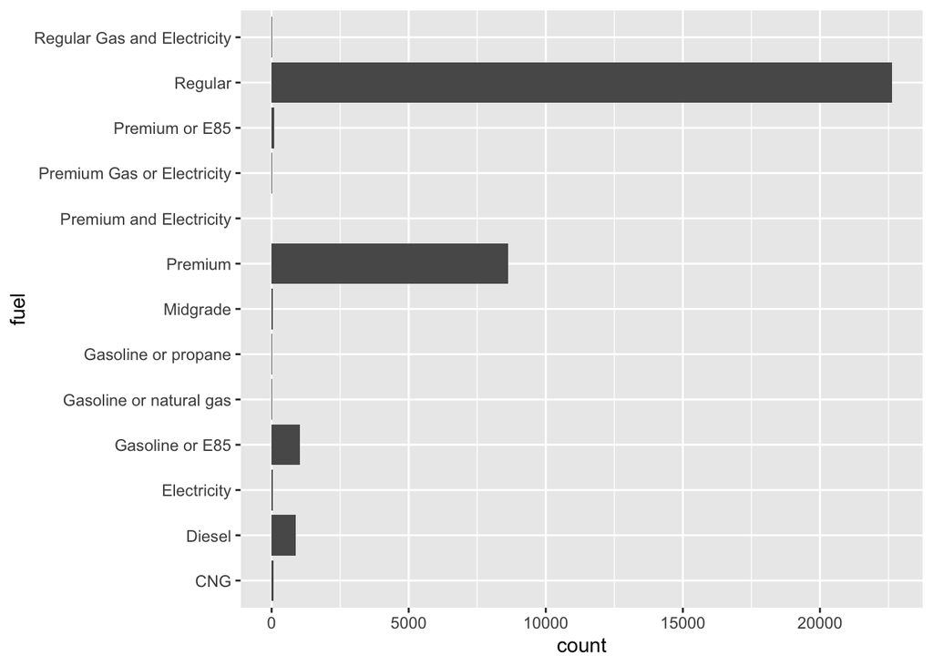

```r
ggplot(vehicles, aes(x = fuel)) +
    geom_bar() +
    coord_flip()
```